# Content

This POPdemog package is also able to extract the demographic information from msprime by first converting an msprime script into a ms-compatible command. We use “msprime2ms.py” to translate the python simulation script into a ms-compatible command. For the ms-compatible command, users must set the 'type' parameter to be “msprime” and copy the command line to an input file or input string. Here we give an example of how to plot the demographic graph from an msprime script copied from the msprime's online documents[<sup>8</sup>](https://msprime.readthedocs.io/en/latest/tutorial.html#demography). Suppose msprime has been successfully installed, and the following msprime's scripts of the demographic events is saved in the file [“demo1.py”](https://github.com/YingZhou001/POPdemog/raw/master/doc/demo1.py).

```
# First we set out the maximum likelihood values of the various parameters
N_A=7300
N_B=2100
N_AF=12300
N_EU0=1000
N_AS0=510
# Times are provided in years, so we convert into generations.
generation_time=25
T_AF=220e3 / generation_time
T_B=140e3 / generation_time
T_EU_AS=21.2e3 / generation_time
# We need to work out the starting (diploid) population sizes based on
# the growth rates provided for these two populations
r_EU=0.004
r_AS=0.0055
N_EU=N_EU0 / math.exp(-r_EU * T_EU_AS)
N_AS=N_AS0 / math.exp(-r_AS * T_EU_AS)
# Migration rates during the various epochs.
m_AF_B=25e-5
m_AF_EU=3e-5
m_AF_AS=1.9e-5
m_EU_AS=9.6e-5
# Population IDs correspond to their indexes in the population
# configuration array. Therefore, we have 0=YRI, 1=CEU and 2=CHB
# initially.
population_configurations=[
msprime.PopulationConfiguration(
    sample_size=0, initial_size=N_AF),
msprime.PopulationConfiguration(
    sample_size=1, initial_size=N_EU, growth_rate=r_EU),
msprime.PopulationConfiguration(
    sample_size=1, initial_size=N_AS, growth_rate=r_AS)
]
migration_matrix=[
[      0, m_AF_EU, m_AF_AS],
[m_AF_EU,       0, m_EU_AS],
[m_AF_AS, m_EU_AS,       0],
]

demographic_events=[
# CEU and CHB merge into B with rate changes at T_EU_AS
msprime.MassMigration(
    time=T_EU_AS, source=2, destination=1, proportion=1.0),
msprime.MigrationRateChange(time=T_EU_AS, rate=0),
msprime.MigrationRateChange(
    time=T_EU_AS, rate=m_AF_B, matrix_index=(0, 1)),
msprime.MigrationRateChange(
    time=T_EU_AS, rate=m_AF_B, matrix_index=(1, 0)),
msprime.PopulationParametersChange(
    time=T_EU_AS, initial_size=N_B, growth_rate=0, population_id=1),
# Population B merges into YRI at T_B
msprime.MassMigration(
    time=T_B, source=1, destination=0, proportion=1.0),
# Size changes to N_A at T_AF
msprime.PopulationParametersChange(
    time=T_AF, initial_size=N_A, population_id=0)
]
```

Then we use the “msprime2ms.py” to convert the demographic description into *ms*-compatible format:

```
python msprime2ms.py demo1.py population_configurations migration_matrix demographic_events
```

where “population_configurations” is the name of the variable for `population_configurations`, “migration_matrix” is the name of the variable for `migration_matrix`, and “demographic_events” is the name of the variable for `demographic_events`. Store the output to the file named “msprime.demo.cmd”

```r
cat("
--structure 3 1 1 1
--population-size 1 0.3075
--population-size 2 0.7431335886597129
--population-growth-rate-change 0 2 160.0
--population-size 3 1.352258276948663
--population-growth-rate-change 0 3 220.0
--migration-matrix x 1.2 0.76 1.2 x 3.8400000000000003 0.76 3.8400000000000003 x
--population-split 0.0212 3 2
--population-size-change 0.0212 2 0.0525
--population-growth-rate-change 0.0212 2 0
--migration-matrix-change 0.0212 3 x 10.0 x 10.0 x x x x x
--population-split 0.14 2 1
--population-size-change 0.22 1 0.1825",
file="msprime.demo.cmd")
```

Then we can use the *PlotMS()* and *PlotMig()* functions to plot the demographic history.

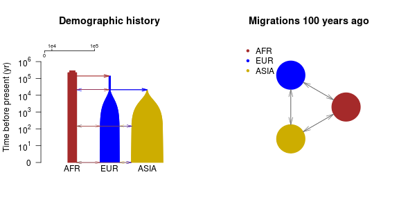

```r
#plot the demographic graph
par(mfrow=c(1,2),las=1)
PlotMS(input.file="msprime.demo.cmd", type="msprime", N4=4*10000,
       size.scale="log", log.base=1.5, inpos=c(1,4,7), time.scale="log10year",
       col.pop=c("brown", "blue", "gold3"), pops=c("AFR", "EUR", "ASIA"),
       cex.lab=1, cex.axis=1, xlab="", length.arrowtip=0.1)
title("Demographic history")
NRuler("topleft", Nsize=c(1e4,1e5), Nlab=c("1e4", "1e5"), N4=40000,
       size.scale="log",log.base=1.5, lwd=1, cex=0.6)
PlotMS(input.file="msprime.demo.cmd", type="msprime", N4=4*10000,
       time.scale="log10year", plot.out=F, demo.out=T )->out;
PlotMig(time_pt=100, demograph_out=out$demograph_out, time.scale="year",
    mig_par=out$mig_par, col.pop=c("brown", "blue", "gold3"),
    size.scale="topology");
legend("topleft", legend=c("AFR", "EUR", "ASIA"), col=c("brown", "blue", "gold3"), pch=20, bty="n")
title("Migrations 100 years ago");unlink("msprime.demo.cmd")
```

[top]

###Support for SCRM simulation script

The POPdemog packagealso supports the scrm simulator[<sup>10].</sup> Here we make an example simulation script that changes `-em 5e-04 2 1 2000 -em 6e-04 2 1 0` in the ms-style command from the file “sample.ms.cmd” to `-eps 5e-04 2 1 0.8`.

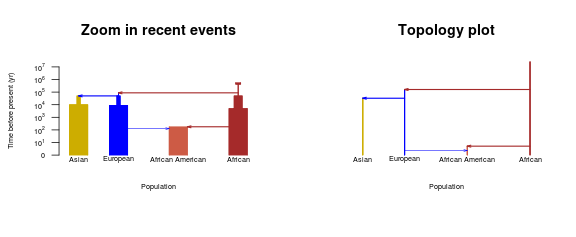

```r
cat("scrm 1 1 -r 25 250001 -t 2.5 -I 4 50 50 50 60 -n 1 10 -n 2 10
    -n 3 10 -n 4 10 -em 0 1 4 0.32 -em 0 4 1 0.32 -em 0 3 4 0.08
    -em 0 4 3 0.08 -eps 5e-04 2 1 0.8 -ej 7e-04 2 4
    -en 0.02 4 2.4 -en 0.035 1 0.77 -en 0.04 3 0.77 -en 0.1997 4 0.0125
    -en 0.1998 3 0.00149253731343284 -en 0.1999 1 0.005 -ej 0.2 3 1
    -em 0.1996 1 4 0 -em 0.1995 4 1 0 -em 0.1994 3 4 0 -em 0.1993 4 3 0
    -en 0.3499 1 0.00117647058823529 -ej 0.35 1 4 -en 1.7 4 1.25", file="scrm.demo.cmd")
par(mfrow=c(1,2), las=1)
PlotMS(input.file="scrm.demo.cmd", type="scrm", N4=10000,
       size.scale="log", log.base =50, inpos=c(3,6,1,9),
       col.pop=c("blue", "coral3", "gold3", "brown"),
       pops=c("European", "African American", "Asian", "African"),
       time.scale="log10year", cex.lab=0.6, cex.axis=0.6, length.arrowtip=0.05, m.adjust=0.05)
title("Zoom in recent events", cex=0.8)
PlotMS(input.file="scrm.demo.cmd", type="scrm", N4=10000,
       size.scale="topology", inpos=c(3,6,1,9),
       col.pop=c("blue", "coral3", "gold3", "brown"),
       pops=c("European", "African American", "Asian", "African"),
       cex.lab=0.6, cex.axis=0.6, length.arrowtip=0.05, ylab="Time before present", m.adjust=0.05)
title("Topology plot", cex=0.8);unlink("scrm.demo.cmd")
```

[top]

##Acknowledgements Xiaowen Tian wrote the python script “msprime2ms.py”.  
Brian Browning and Sharon Browning helped proof-read this tutorial and R document.

[top]

##References

[<sup>2]:</sup> Chen, G. K., P. Marjoram, and J. D. Wall. “Fast and Flexible Simulation of DNA Sequence Data.” Genome Research 19.1 (2008): 136-42. [<sup>6]:</sup> Hellenthal, G., and M. Stephens. “MsHOT: Modifying Hudson's Ms Simulator to Incorporate Crossover and Gene Conversion Hotspots.” Bioinformatics 23.4 (2006): 520-21. [<sup>1]:</sup> Hudson, R. R. “Generating Samples under a Wright-Fisher Neutral Model of Genetic Variation.” Bioinformatics 18.2 (2002): 337-38. [<sup>5]:</sup> Moorjani, Priya, et al. “A Genetic Method for Dating Ancient Genomes Provides a Direct Estimate of Human Generation Interval in the Last 45,000 Years.” Proceedings of the National Academy of Sciences, vol. 113, no. 20, Feb. 2016, pp. 5652–5657. [<sup>3]:</sup> Shlyakhter, Ilya, Pardis C. Sabeti, and Stephen F. Schaffner. “Cosi2: An Efficient Simulator of Exact and Approximate Coalescent with Selection | Bioinformatics | Oxford Academic.” OUP Academic. Oxford University Press, 22 Aug. 2014. [<sup>4]:</sup> Vernot, B., S. Tucci, J. Kelso, J. G. Schraiber, A. B. Wolf, R. M. Gittelman, M. Dannemann, S. Grote, R. C. Mccoy, H. Norton, L. B. Scheinfeldt, D. A. Merriwether, G. Koki, J. S. Friedlaender, J. Wakefield, S. Paabo, and J. M. Akey. “Excavating Neandertal and Denisovan DNA from the Genomes of Melanesian Individuals.” Science 352.6282 (2016): 235-39. [<sup>7]:</sup> Jerome Kelleher, Alison M Etheridge and Gilean McVean (2016), Efficient Coalescent Simulation and Genealogical Analysis for Large Sample Sizes, PLoS Comput Biol 12(5): e1004842.

[<sup>9]:</sup> Gutenkunst RN, Hernandez RD, Williamson SH, Bustamante CD (2009) Inferring the Joint Demographic History of Multiple Populations from Multidimensional SNP Frequency Data. PLOS Genetics 5(10): e1000695. https://doi.org/10.1371/journal.pgen.1000695 [<sup>10]:</sup> Paul R. Staab, Sha Zhu, Dirk Metzler and Gerton Lunter. scrm: efficiently simulating long sequences using the approximated coalescent with recombination. Bioinformatics (2015) 31 (10): 1680-1682.